# Introductory steps - phase 1

The introductory steps are a guided process through which:

- we spell out clearly how R can be used for a basic data story
- we introduce the reader to the basics of R, iterating on each notion learned in the previous step
- we contextualise the step within a data-driven story writing workflow.

## Main intro

*interactive quiz used as a way to start engaging the visitor right away, and to get statistics from various populations*

```
Are you a journalist?
-> Yes -> No

|____(if no) this tutorial is delibarately, intensely, exclusively focused on journalists. If you want to continue you'll have to pretend to be a journalist and, believe us, it's not pleasant. Do you still want to continue?

____ -> Yes -> No

     |
     |____ (if yes) Have you ever heard about this thing we call R?

     ____-> Yes -> No
         |
         |____ (if no) Well, despite its mysterious and concise name, R is an open source programming
         language and environment for statistical computing, widely used among data analysts, statisticians,
         programmers and more recently, by data journalists.   Our mission today will be to convince you
         that R is worth your precious time and will help you improve your work in the newsroom.

         |
         |____ (if yes) Do you already use R your work?

          ____-> Yes -> No

                |
                |____________ (if yes) What follows is a beginner tutorial for R-newbies.
                You could jump directly to [our list of R recipes]() or still follow the introduction tutorial
                to steal ideas for your own R trainings (we know who you are!).

                |
                |____________ (if no) So an R atheist? Or maybe agnostic?
                Our mission will be to convice you to actually start using R in your workflow.
                If we fail, we allow you the privilege to send us an angry tweet.

  --------------------
 | Challenge accepted |
  --------------------
```

## The context

*Here we set up the story that will be used to contextualise all actions in the tutorial*

A referendum in your country is over and you are tasked to do a post-election analysis. You have data about the number of votes, demographics and geographic distribution of the votes. In order to see what would make a good story, you decide to analyse and visualise the data. Even though you normally work with spreadsheets, you want to try R. Here are a few reasons why:

| Spreadsheet | R |
| --- | --- |
| It’s a “point and click program” | You write a functions directly in the R interface and R does all the magic |
| If you want to repeat a process you have to do it every time | R allows for automation of processes that have to be repeated. Write once, reuse several times: Not only can you update your code easily, but you can easily share it with other projects. |
| Only allows some types of files | Can load different kinds of files that can be complicated or impossible to work with in a spreadsheet |
| Allows you to make some graphics, but you are limited by the program to what type and what do they look like | Allows you to customize every aspect of your visualization |
| You go through your analyzing process once and you can forget about making it immediately reproducible for someone else | Allows you to save the code through which you processed your database. This makes the whole methodology immediately reproducible by anyone else whom you shared the script with. |
| … | … |

> **Wait, what?**

> how do I even know how write R code? I’m not a programmer!

> Well you don’t need to: as long as you understand what you want to do, you will probably find an answer in the documentation, tutorials or existing projects.

We are going to guide you in each step, don’t worry, it won’t be that hard. Let’s start with getting the data.

## Getting the data

You stretch your arms, grab a coffee, and off you go! First, you have to find the electoral data. For this example, we are going to analyze the Brexit Referendum Results. The results data, compiled by the Electoral Comission are available [here](https://github.com/school-of-data/r-consortium-proposal/blob/master/material/lessons/results.csv) in .csv format

You also want to align it with a dataset which gives various demographic information about regions, in order to try various analyses. We are going to use 2 files: a .dta file (a filetype that you can not open in Excel) that is available [here](https://github.com/school-of-data/r-consortium-proposal/blob/master/material/lessons/demographics2.dta) and a .xlsx file available [here](https://github.com/school-of-data/r-consortium-proposal/blob/master/material/lessons/demographics1.xlsx).

Metadata:

*Results*

- `id` Unique id
- `Region_Code` Region Code
- `Region` Region Name
- `Area_Code` Unique area code
- `Area` Area Name
- `HASC_code` [HASC](https://en.wikipedia.org/wiki/Hierarchical_administrative_subdivision_codes) code
- `Electorate` Number of registered voters
- `ExpectedBallots` Expected ballots
- `VerifiedBallotPapers` Verified Ballots
- `Pct_Turnout` Percentage of voter turnout. VerifiedBallotPapers/Electorate
- `Votes_Cast` Casted Votes
- `Valid_Votes` Number of Valid votes
- `Remain` Number of “Remain” votes
- `Leave` Number of “Leave” votes
- `Rejected_Ballots` Number of rejected ballots

*Demographics1*

- `new_id` unique Id
- `area_code` Unique area code
- `area_name` Area Name
- `median_age` Median age of residents
- `prof_ocu_1` Percentage of residents with higher and intermediate professional occupations
- `prof_ocu_2` Percentage of residents with junior professional occupations

*Demographics2*

- `new_id` unique Id
- `area_code` Unique area code
- `area_name` Area Name
- `born_uk` Percentage of residents born in the UK
- `no_educ` Percentage of residents with no formal education
- `higher_educ` Percentage of residents with higher education

Let’s download those 3 files and store them in a folder called `electoral-data`. You must have 3 files in your folder: `results.cvs` `demographics1.xlsx` `demographics2.dta`

Now let’s try reading in the data: 1. Open your R editor (e.g. RStudio) 2. Set your working directory to `electoral-data`. To do this enter

```r
setwd("/PATH/electoral-data")
```

in the console. Then, we are going to need two specialised packages to read .dta and .xlsx files into R: `xlsx` and `foreign`. To install the packages run

```r
install.packages("xlsx")
install.packages("foreign")
```

To load the packages run

```r
library("xlsx")
library("foreign")
```

Now we can read the data:

```r
# read results data
results <- read.csv("https://raw.githubusercontent.com/school-of-data/r-consortium-proposal/master/material/lessons/results.csv", header = TRUE)

# read demographic data
demographic1 <- read.xlsx("demographics1.xlsx", sheetIndex = 1)
demographic2 <- read.dta("demographics2.dta")
```

(Note the the hash: it can be used to add comments. You should use it to help future you remember what you did.) Note also than the “string” or text on the left of the <- can be whatever name you want it to be, and the function on the right side of it is assigned to that number. This is what in R is called creating an object and assigning it with a function or value.

See? That was easy! Now you have your data loaded into the program and can start working.

Are you seeing the magic yet?

- A simple line of code can replace cumbersome manual operations that you have to do in Excel to import the data
- R loads all sort of file formats, and doesn’t complain
- Write once, reuse several times: Not only you can update your code easily, but you can easily share it with other projects.
- Your stagiaire doesn’t know where to find the relevant data? no problem, the links are all in the R code!

> **Let’s review the commands we learned in this step:**
> - Set the folder you work in (working directory) `setwd()`
> - Install Packages `install.packages()`
> - Load Libraries `library()`
> - Read files `read.csv` `read.xlsx` `read.dta`
> - Creating objects and assigning values to them
> - Add code comments `# my comment`

> **Want to learn what other types of data can be imported into R**

> [Check this!](https://www.datacamp.com/community/tutorials/r-data-import-tutorial#gs.oZSkvFo)

Now let’s move on with the analysis!

## Verifying the data

Now that you have imported your data into R, it’s time to start exploring it. Here are some useful commands:

- `view()` shows your dataframe with all the variables and observations
- `names()` shows the collumn names of the data frame

```r
names(results)
```

```
##  [1] "id"                      "Region_Code"
##  [3] "Region"                  "Area_Code"
##  [5] "Area"                    "HASC_code"
##  [7] "Electorate"              "ExpectedBallots"
##  [9] "VerifiedBallotPapers"    "Pct_Turnout"
## [11] "Votes_Cast"              "Valid_Votes"
## [13] "Remain"                  "Leave"
## [15] "Rejected_Ballots"        "No_official_mark"
## [17] "Voting_for_both_answers" "Writing_or_mark"
## [19] "Unmarked_or_void"        "Pct_Remain"
## [21] "Pct_Leave"               "Pct_Rejected"
```

```r
names(demographic1)
```

```
## [1] "new_id"     "area_code"  "area_name"  "median_age" "prof_ocu_1"
## [6] "prof_ocu_2"
```

```r
names(demographic2)
```

```
## [1] "new_id"      "area_code"   "area_name"   "born_uk"     "no_educ"
## [6] "higher_educ"
```

```r
str(results)
```

```
## 'data.frame':    382 obs. of  22 variables:
##  $ id                     : int  108 109 112 113 110 111 184 185 186 187 ...
##  $ Region_Code            : Factor w/ 12 levels "E12000001","E12000002",..: 6 6 6 6 6 6 6 6 6 6 ...
##  $ Region                 : Factor w/ 12 levels "East","East Midlands",..: 1 1 1 1 1 1 1 1 1 1 ...
##  $ Area_Code              : Factor w/ 382 levels "E06000001","E06000002",..: 31 32 33 34 54 55 61 62 63 64 ...
##  $ Area                   : Factor w/ 382 levels "Aberdeen","Aberdeenshire",..: 240 186 287 333 21 58 50 99 123 162 ...
##  $ HASC_code              : Factor w/ 168 levels "GB.AB","GB.AG",..: 112 84 136 145 7 7 25 25 25 25 ...
##  $ Electorate             : int  120892 127612 128856 109897 119530 204004 80108 62435 71447 128486 ...
##  $ ExpectedBallots        : int  87474 84633 93948 79969 86136 158904 57871 48129 52653 99996 ...
##  $ VerifiedBallotPapers   : int  87469 84636 93939 79954 86136 158896 57860 48120 52649 99990 ...
##  $ Pct_Turnout            : num  72.3 66.3 72.9 72.8 72.1 ...
##  $ Votes_Cast             : int  87469 84616 93939 79950 86135 158894 57852 48124 52649 99990 ...
##  $ Valid_Votes            : int  87392 84481 93870 79916 86066 158804 57799 48086 52626 99927 ...
##  $ Remain                 : int  34176 36708 39348 22151 41497 69670 42682 23599 15055 45729 ...
##  $ Leave                  : int  53216 47773 54522 57765 44569 89134 15117 24487 37571 54198 ...
##  $ Rejected_Ballots       : int  77 135 69 34 69 90 53 38 23 63 ...
##  $ No_official_mark       : int  0 0 0 0 0 0 0 0 0 0 ...
##  $ Voting_for_both_answers: int  32 85 21 8 26 34 13 18 10 31 ...
##  $ Writing_or_mark        : int  7 0 0 3 1 1 0 0 1 0 ...
##  $ Unmarked_or_void       : int  38 50 48 23 42 55 40 20 12 32 ...
##  $ Pct_Remain             : num  39.1 43.5 41.9 27.7 48.2 ...
##  $ Pct_Leave              : num  60.9 56.5 58.1 72.3 51.8 ...
##  $ Pct_Rejected           : num  0.09 0.16 0.07 0.04 0.08 0.06 0.09 0.08 0.04 0.06 ...
```

Now that you know the variables of your databases is time to start with the cleaning part.

## Cleaning the data

Before you can start your analysis, you need a clean database with all the information. Nevertheless you have the information scattered in 3 different data.frames, which you would like to combine.

Our objective is to add the demographic variables `median_age` `prof_ocu_1` `prof_ocu_2` `born_uk` `no_educ` and `higher_educ` to the results database. But in order to do this, we need a common variable in all the datasets. In the previous step, where we explored the data you can see that the three databases have the variable: `area_code`.

That common variable will allow us to merge the databases using the `merge` function.

Simply type:

```r
## merge the data sets
mydata <- merge(results, demographic1, by.x = "Area_Code", by.y = "area_code")
mydata <- merge(mydata, demographic2, by.x = "Area_Code", by.y = "area_code")

## list all variables in mydata
names(mydata)
```

```
##  [1] "Area_Code"               "id"
##  [3] "Region_Code"             "Region"
##  [5] "Area"                    "HASC_code"
##  [7] "Electorate"              "ExpectedBallots"
##  [9] "VerifiedBallotPapers"    "Pct_Turnout"
## [11] "Votes_Cast"              "Valid_Votes"
## [13] "Remain"                  "Leave"
## [15] "Rejected_Ballots"        "No_official_mark"
## [17] "Voting_for_both_answers" "Writing_or_mark"
## [19] "Unmarked_or_void"        "Pct_Remain"
## [21] "Pct_Leave"               "Pct_Rejected"
## [23] "new_id.x"                "area_name.x"
## [25] "median_age"              "prof_ocu_1"
## [27] "prof_ocu_2"              "new_id.y"
## [29] "area_name.y"             "born_uk"
## [31] "no_educ"                 "higher_educ"
```

You now have a new dataframe `mydata` with the electoral and the demographic information. Nevertheless we need to further clean the database.

To analyze the data we also need the percentage of Remain, Leave and Rejected votes for each area. We are going to create those three variables:

```r
mydata$perc_remain <- (mydata$Remain / mydata$Valid_Votes) * 100
mydata$perc_leave <- (mydata$Leave / mydata$Valid_Votes) * 100
mydata$perc_rejected <- (mydata$Rejected_Ballots / mydata$Votes_Cast) * 100
```

Also we want to sum `prof_ocu_1` and `prof_ocu_2` to create a new variable that contains the percentage of residents in each area with professional occupations:

```r
mydata$prof_ocu <- mydata$prof_ocu_1 + mydata$prof_ocu_2
```

We can also create a new categorical variable `Result` that shows which areas voted to leave and which voted to remain. To do this we are going to use the `ifelse()` function. To look at the number of areas who voted for and against remaining we can use the `table()` function.

```r
## This fuction creates a new variable that asigns the value 1 if the remain percentage is less than 50,
## and 0 otherwise
mydata$result <- ifelse(mydata$perc_remain < 50, 1, 0)

## Table of the result
table(mydata$result)
```

```
##
##   0   1
## 118 263
```

Now we can add labels to the variable `Result`

```r
#Adding labels to 'Result'
mydata$result <- factor(mydata$result,
                        levels = c(1, 0),
                        labels = c("leave", "remain"))

## Table of the result
table(mydata$result)
```

```
##
##  leave remain
##    263    118
```

We can also create a new categorical variable that allows to group the Remain vote in different categories:

```r
## create 4 categories of voting percentages
mydata$Remain_cat <- cut(mydata$perc_remain, breaks = c(0, 25, 50, 75, 100))
table(mydata$Remain_cat)
```

```
##
##   (0,25]  (25,50]  (50,75] (75,100]
##        1      262      112        6
```

Now we can add labels to the variable `Remain_cat`

```r
mydata$Remain_cat <- factor(mydata$Remain_cat, labels = c("very low", "low", "high", "very high"))
table(mydata$Remain_cat)
```

```
##
##  very low       low      high very high
##         1       262       112         6
```

We are almost done, don’t give up just yet! Now to finish we want to aggregate regional data in new varaibles, in order the see the voting results by region. A simple way to do this is with the `summarise()` function from the `dplyr` package. If you don’t have the package installed, install it with the command `install.packages("dplyr")`.

```r
library("dplyr")
datahasc <- summarise(group_by(mydata, HASC_code),        ## Group mydata by HASC code
                        Valid_Votes = sum(Valid_Votes),  ## Create a variable Valid_Votes which is the number of valid votes per HASC code, i.e. the sum of valid votes in the areas of the HASC code
                        Remain = sum(Remain),
                        Leave = sum(Leave))

## Calculate the percentages
datahasc$perc_remain <- (datahasc$Remain / datahasc$Valid_Votes)*100
datahasc$perc_leave <- (datahasc$Leave/ datahasc$Valid_Votes)*100

datahasc
```

```
## # A tibble: 167 × 6
##    HASC_code Valid_Votes Remain  Leave perc_remain perc_leave
##       <fctr>       <int>  <int>  <int>       <dbl>      <dbl>
## 1      GB.AB       48696  29494  19202    60.56760   39.43240
## 2      GB.AG       59258  32747  26511    55.26174   44.73826
## 3      GB.AR      104714  63985  40729    61.10453   38.89547
## 4      GB.AS      138961  76445  62516    55.01184   44.98816
## 5      GB.AY       37951  18618  19333    49.05800   50.94200
## 6      GB.BA       73880  27750  46130    37.56091   62.43909
## 7      GB.BD      244870 111167 133703    45.39837   54.60163
## 8      GB.BE      121404  72523  48881    59.73691   40.26309
## 9      GB.BG       34802  13215  21587    37.97196   62.02804
## 10     GB.BH      146675 100648  46027    68.61974   31.38026
## # ... with 157 more rows
```

Now that you have cleaned your data, you’re ready to start the analysis!

**Are you convinced yet that R is worth your time?**  
____ not really  
____ hmmm, I need to see more to decide  
____ yes, R won my heart

**Let’s list some advantages of R so far:** * With simple lines of code you can rearrange your data, create new variables, delete observations * Something went wrong? Don’t worry, just fix your code, run it and the error goes away easily * You can keep your original datafiles in the workspace if you need to review them.

> **Let’s review what we learned in this step:**
> - Merge datasets `merge()`
> - Create new variables
> - Create new categorical variables and asign labels
> - Create a new data set with summaries of an existing data set

## Analyze

Let’s start with the most fun part. You need to write a story based on those electoral results, and you already have some questions you want to answer: - Which areas voted to remain or to leave? - Which regions? - Which were the more divided regions? - How do the demographic variables correlate with the leave and remain percentage of votes?

First we need to tabulate the data:

```r
## How many areas voted to remain or leave
table(mydata$result)
```

```
##
##  leave remain
##    263    118
```

```r
prop.table(table(mydata$result))
```

```
##
##     leave    remain
## 0.6902887 0.3097113
```

You can see that 69% of the areas voted to leave the European Union. Now let’s see how are they are distributed by Region creating a two frequency table that shows row percentages. To do that we are going to use the `CrossTab()` function in the `gmodels` package (rember to install it with `install.packages("gmodels")`):

```r
library("gmodels")
CrossTable(mydata$Region, mydata$result, digits=3, max.width = 5, expected = FALSE,
           prop.r = TRUE, prop.c = FALSE, prop.t = FALSE, prop.chisq = FALSE)
```

```
##
##
##    Cell Contents
## |-------------------------|
## |                       N |
## |           N / Row Total |
## |-------------------------|
##
##
## Total Observations in Table:  381
##
##
##                          | mydata$result
##            mydata$Region |     leave |    remain | Row Total |
## -------------------------|-----------|-----------|-----------|
##                     East |        42 |         5 |        47 |
##                          |     0.894 |     0.106 |     0.123 |
## -------------------------|-----------|-----------|-----------|
##            East Midlands |        38 |         2 |        40 |
##                          |     0.950 |     0.050 |     0.105 |
## -------------------------|-----------|-----------|-----------|
##                   London |         5 |        28 |        33 |
##                          |     0.152 |     0.848 |     0.087 |
## -------------------------|-----------|-----------|-----------|
##               North East |        11 |         1 |        12 |
##                          |     0.917 |     0.083 |     0.031 |
## -------------------------|-----------|-----------|-----------|
##         Northern Ireland |         0 |         1 |         1 |
##                          |     0.000 |     1.000 |     0.003 |
## -------------------------|-----------|-----------|-----------|
##               North West |        32 |         7 |        39 |
##                          |     0.821 |     0.179 |     0.102 |
## -------------------------|-----------|-----------|-----------|
##                 Scotland |         0 |        32 |        32 |
##                          |     0.000 |     1.000 |     0.084 |
## -------------------------|-----------|-----------|-----------|
##               South East |        43 |        24 |        67 |
##                          |     0.642 |     0.358 |     0.176 |
## -------------------------|-----------|-----------|-----------|
##               South West |        28 |         9 |        37 |
##                          |     0.757 |     0.243 |     0.097 |
## -------------------------|-----------|-----------|-----------|
##                    Wales |        17 |         5 |        22 |
##                          |     0.773 |     0.227 |     0.058 |
## -------------------------|-----------|-----------|-----------|
##            West Midlands |        29 |         1 |        30 |
##                          |     0.967 |     0.033 |     0.079 |
## -------------------------|-----------|-----------|-----------|
## Yorkshire and The Humber |        18 |         3 |        21 |
##                          |     0.857 |     0.143 |     0.055 |
## -------------------------|-----------|-----------|-----------|
##             Column Total |       263 |       118 |       381 |
## -------------------------|-----------|-----------|-----------|
##
##
```

```r
# Note that we set the prop.r = TRUE in order to show row percetages.
# If we wanted for instance to show column percentages
# we can set prop.c = TRUE
```

With that table you can see that the only regions in wich the majority of areas voted to remain in the EU are located in London, Scotland and Northern Ireland. This could be interesting for your story!

We can also calculate some summary statistics for the `perc_remain` variable:

```r
summary(mydata$perc_remain)
```

```
##    Min. 1st Qu.  Median    Mean 3rd Qu.    Max.
##   24.44   39.65   45.73   46.88   52.85   78.62
```

```r
table(mydata$Remain_cat)
```

```
##
##  very low       low      high very high
##         1       262       112         6
```

You can see that only one area had a very low vote to Remain with 24.4% of the vote.

We can also tabulate the 10 areas with the highest Leave vote:

```r
## order data by percentage of leave votes
order_leave <- order(mydata$perc_leave, decreasing = TRUE)
mydata <- mydata[order_leave, ]

## show the first 10 observations, show only some of the variables
mydata[1:10, c("Region", "Area", "Leave", "Remain", "perc_leave")]
```

```
##                       Region                    Area Leave Remain
## 165            East Midlands                  Boston 22974   7430
## 169            East Midlands           South Holland 36423  13074
## 102                     East            Castle Point 37691  14154
## 34                      East                Thurrock 57765  22151
## 174                     East          Great Yarmouth 35844  14284
## 63                      East                 Fenland 37571  15055
## 197            East Midlands               Mansfield 39927  16417
## 73             East Midlands                Bolsover 29730  12242
## 166            East Midlands            East Lindsey 56613  23515
## 12  Yorkshire and The Humber North East Lincolnshire 55185  23797
##     perc_leave
## 165   75.56243
## 169   73.58628
## 102   72.69939
## 34    72.28215
## 174   71.50495
## 63    71.39247
## 197   70.86291
## 73    70.83294
## 166   70.65320
## 12    69.87035
```

So far you have answered some of your questions: the majority of areas in the UK voted to leave the EU. London, Scotland and Northern Ireland voted by majority to Remain.

So it’s time to go deeper in the analysis. We can calculate some correlations between the leave vote and some of the demographic variables. The hyphotesis is that the regions with older population, less educated residents and less diverse voted to Leave the EU.

Now let’s calculate some correlations. To calculate a correlation between two variables just use the fuction `cor()` and plot it using `plot(x, y)`:

```r
cor(mydata$perc_leave, mydata$no_educ)
```

```
## [1] 0.5563877
```

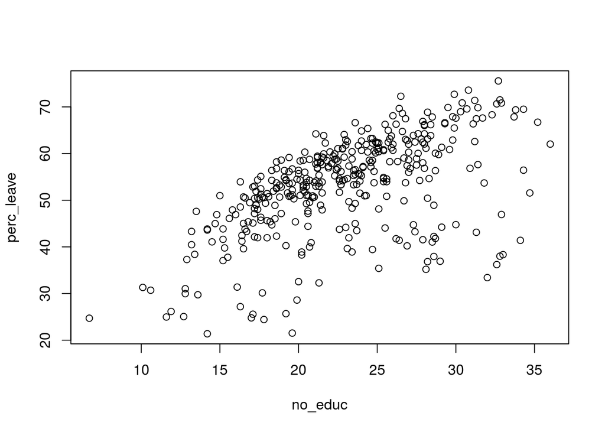

```r
plot(perc_leave ~ no_educ, data = mydata)
```

To see if our correlation is statistically significant we can use a linear model:

```r
### look at Pr(<|t|) in the no_educ row. The p-value is very small
### => statistically significant linear relation between no_educ and perc_leave
model <- lm(perc_leave ~ no_educ, data = mydata)
summary(model)
```

```
##
## Call:
## lm(formula = perc_leave ~ no_educ, data = mydata)
##
## Residuals:
##     Min      1Q  Median      3Q     Max
## -30.006  -2.928   2.432   6.015  15.049
##
## Coefficients:
##             Estimate Std. Error t value Pr(>|t|)
## (Intercept)  27.4191     2.0207   13.57   <2e-16 ***
## no_educ       1.1250     0.0863   13.04   <2e-16 ***
## ---
## Signif. codes:  0 '***' 0.001 '**' 0.01 '*' 0.05 '.' 0.1 ' ' 1
##
## Residual standard error: 8.663 on 379 degrees of freedom
## Multiple R-squared:  0.3096, Adjusted R-squared:  0.3077
## F-statistic: 169.9 on 1 and 379 DF,  p-value: < 2.2e-16
```

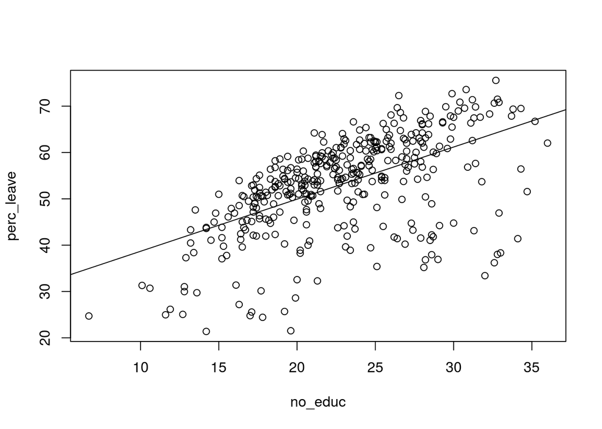

```r
### visualise the estimated relation
plot(perc_leave ~ no_educ, data = mydata)
abline(model)
```

*Do we even want to go into stats so deeply?*

To calculate a correlation matrix, let’s create a new dataframe only with the varaibles we need and then use the `cor()` function again:

```r
datacor <- select(.data = mydata,
                  perc_leave, perc_remain, median_age, born_uk, no_educ, higher_educ, prof_ocu)

#Lets calculate the correlation matrix
cor(datacor)
```

```
##             perc_leave perc_remain median_age    born_uk    no_educ
## perc_leave   1.0000000  -1.0000000  0.3344219  0.4781973  0.5563877
## perc_remain -1.0000000   1.0000000 -0.3344219 -0.4781973 -0.5563877
## median_age   0.3344219  -0.3344219  1.0000000  0.7368753  0.1892295
## born_uk      0.4781973  -0.4781973  0.7368753  1.0000000  0.4524213
## no_educ      0.5563877  -0.5563877  0.1892295  0.4524213  1.0000000
## higher_educ -0.7708179   0.7708179 -0.2176862 -0.5447494 -0.8812980
## prof_ocu    -0.5849986   0.5849986 -0.1497925 -0.4035716 -0.9095549
##             higher_educ   prof_ocu
## perc_leave   -0.7708179 -0.5849986
## perc_remain   0.7708179  0.5849986
## median_age   -0.2176862 -0.1497925
## born_uk      -0.5447494 -0.4035716
## no_educ      -0.8812980 -0.9095549
## higher_educ   1.0000000  0.8868166
## prof_ocu      0.8868166  1.0000000
```

You can see that there’s a positive correlation between the Remain vote and the areas with a high number of residents with higher education and professional occupations. On the contrary, there seem to be a positive correlation between the areas with a higher proportion of no educated residents and the leave vote.

*Don’t forget: Correlation DOES NOT imply causation!!

But wait, we can understand better the data if we plot a correlation matrix. To do that we need the package `GGally` and the package `ggplot2`:

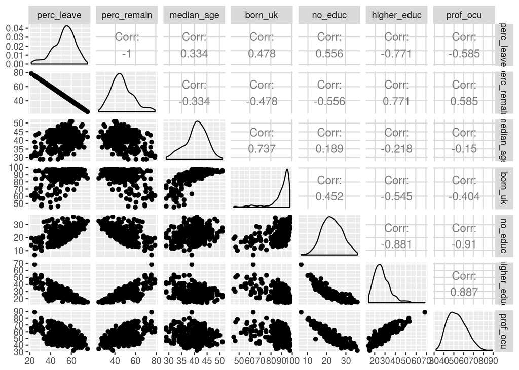

```r
library("ggplot2")
library("GGally")
ggpairs(datacor)
```

Now you have some interesting insights and can start writing your story! But wait! how about we try some nice visualizations for the data?

## Visualize

A common task in the work of a journalist is to bring the results into a form that are nice to look at. Often this form is a map. For this we need a couple of packages:

```r
## remeber to install all packages
## with install.packages()
library("raster")
library("maptools")
library("broom")
library("ggplot2")
```

Maps are complicated and on some computers the code below won’t work. A fix is to use

```r
library("gpclib")
gpclibPermit()
```

BUT the licence for gpclib is not Free or Open Source and explicitly forbids commercial use, which is why we recommend not to use it if not needed.

Now let’s get started: First we need to get the spatial data needed to create a map. `getData` can get you geographic data from all over the world from different sources. We use [GADM.org](http://www.gadm.org/) as a source here. The country of interest is Great Britain (GBR) and we need info on 2nd level administrative subdivision. Check out what other geographic information you can get by typing `?raster::getData` into the R console.

```r
## get the spatial data for Great Britain (GBR)
gbr_sp <- getData("GADM", country = "GBR", level = 2)
```

Next, we convert the data to a data frame we can work with (this is just a technical detail you don’t need to understand at this point):

```r
gbr <- fortify(gbr_sp, region = "HASC_2")
str(gbr)
```

```
## 'data.frame':    432920 obs. of  7 variables:
##  $ long : num  -5.46 -5.46 -5.46 -5.46 -5.46 ...
##  $ lat  : num  55.6 55.6 55.6 55.6 55.6 ...
##  $ order: int  1 2 3 4 5 6 7 8 9 10 ...
##  $ hole : logi  FALSE FALSE FALSE FALSE FALSE FALSE ...
##  $ piece: Factor w/ 234 levels "1","2","3","4",..: 1 1 1 1 1 1 1 1 1 1 ...
##  $ id   : chr  "GB.AB" "GB.AB" "GB.AB" "GB.AB" ...
##  $ group: Factor w/ 1113 levels "GB.AB.1","GB.AB.2",..: 1 1 1 1 1 1 1 1 1 1 ...
```

Our data set `datahasc` has no detailed info on the districts in Northern Ireland (check out for yourself `datahasc$HASC_code`) so we have to change the HASC code (gbr$id) for these districts to just “Northern Ireland” to be able to merge the geographical data with the voting results.

```r
# (1) get data from spatial object which contains info on HASC code and which
#     of the codes correspond to Northern Ireland
mapdat <- gbr_sp@data

# (2) get the HASC codes that correspond to Northern Ireland
NI_HASC <- mapdat$HASC_2[mapdat$NAME_1 == "Northern Ireland"]

# (3) change the relevant HASC codes in gbr to "Northern Ireland"
table(gbr$id[gbr$id %in% NI_HASC])
```

```
##
## GB.AD GB.AM GB.AN GB.BB GB.BF GB.BL GB.BY GB.CF GB.CK GB.CL GB.CR GB.CS
##  4892    67    70    52   456    72    57   491    57   642    53    27
## GB.DN GB.DW GB.FE GB.LB GB.LD GB.LM GB.LR GB.MF GB.MY GB.ND GB.NM GB.NW
##   100  3835   169    52   359   860  1953    71  2293   680   979   174
## GB.OM GB.SB
##    76   128
```

```r
gbr$id[gbr$id %in% NI_HASC] <- "Northern Ireland"
```

Now we can merge

```r
## Merge the map data with the brexit data for the HASC areas we created earlier
gbr_brexit <- merge(gbr, datahasc, by.x = "id", by.y = "HASC_code", all.x = TRUE)
```

For plotting spatial data it is important that the order is correct. Let’s get the order right: fortunately we have a variable `order` in our gbr_brexit data set (you always get the order with the geographic data, see `str(gbr)`. The function `order()` gives us the info on how we need to reorder our data set:

```r
ord <- order(gbr_brexit$order)
gbr_brexit <- gbr_brexit[ord, ]
```

Now we can plot the map. `ggplot` is like lego bricks. In this case our foundation is the `gbr_brexit` data. Longitude and latitude variables (`long` and `lat`) go on the x and y axes, `group` is a variable with the geographic details needed and we want to color (`fill`) the administrative divisions according to the percentage of remain votes `perc_remain`. `geom_polygon` is responsible for plotting the colored polygons:

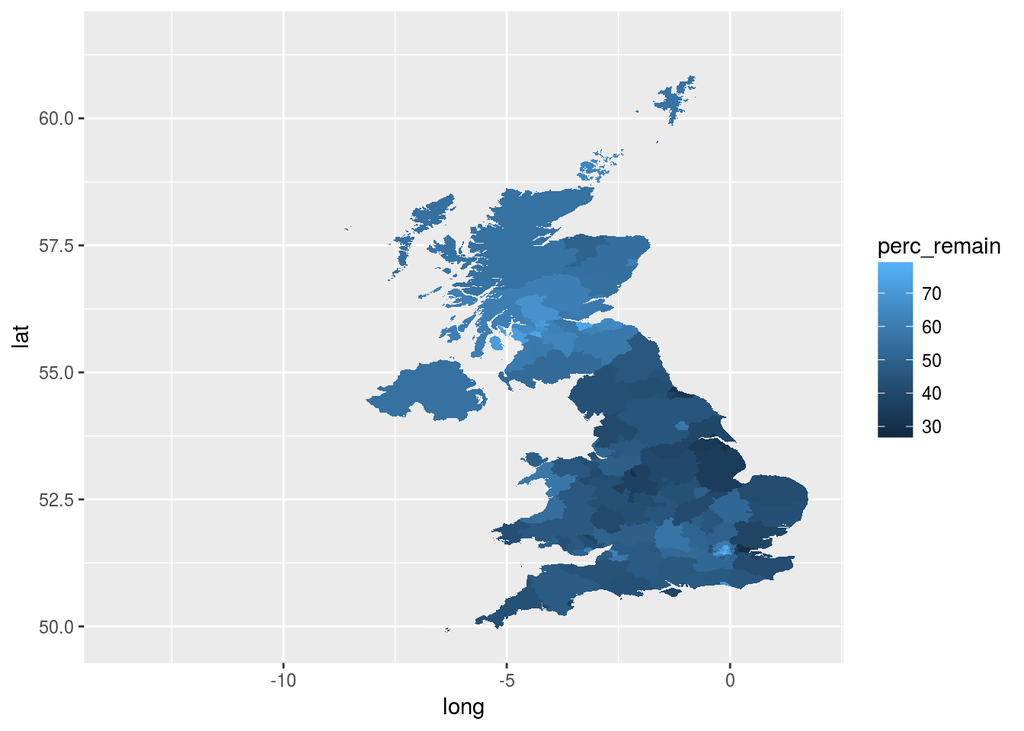

```r
p1 <- ggplot(data = gbr_brexit, aes(x = long, y = lat, group = group, fill = perc_remain)) +
  geom_polygon()
p1
```

But this map is not quite correct, we need to make sure that it has the right proportions:

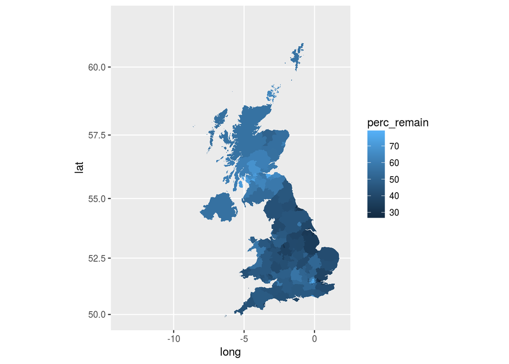

```r
p2 <- p1 + coord_map()
p2
```

Also it seems like the x axis is a bit too long, let’s shorten it:

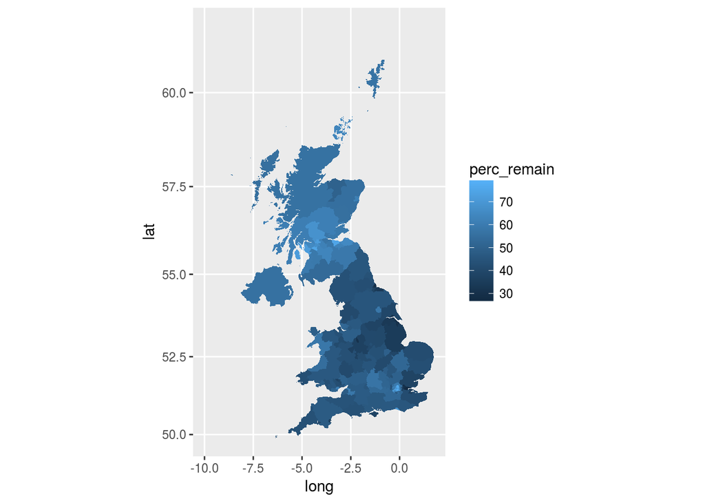

```r
p3 <- p2 + xlim(-10, NA)
p3
```

We can now add nicer x- and y-axis labels as well as the legend title:

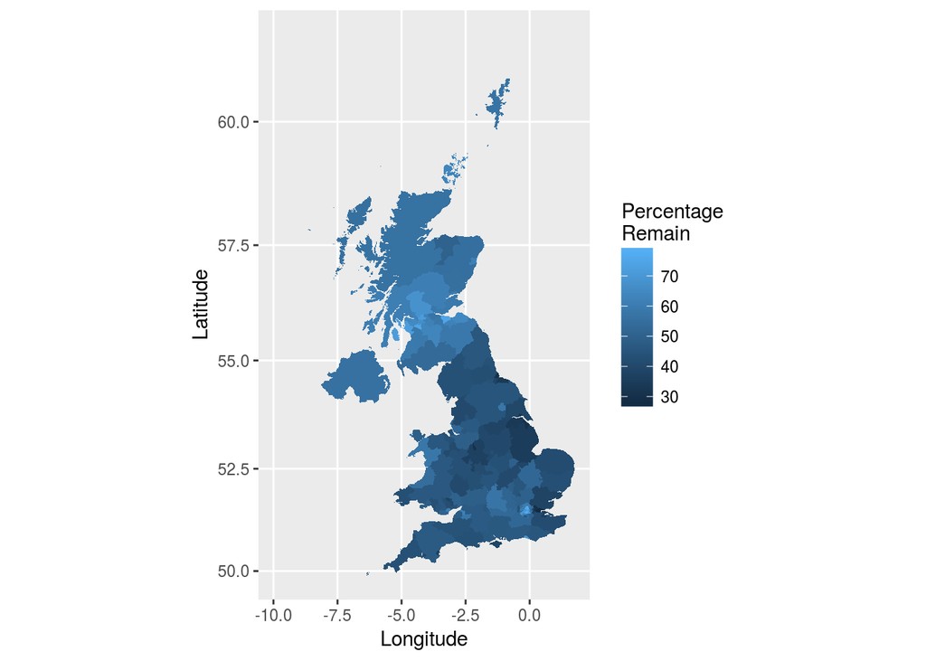

```r
p3 + labs(x = "Longitude",
          y = "Latitude",
          fill = "Percentage\nRemain") # pro tip: \n creates a line break
```

TADA!

This was the last step! Are you convinced yet? If not, check out other scenarios or send us an angry tweet

## Introductory steps - Recipes